# modelling_SRvsQmean.R

barbarossav

2020-03-18

```r
# set wd
knitr::opts_knit$set(root.dir = 'C:/Users/barbarossav/Documents/projects/SDRs')
```

load assigned variables from MASTER.R

```r
source('R/MASTER.R')

# what has been loaded
as.list(.GlobalEnv)
```

```
## $MAX_OVERLAP_PERC
## [1] 50
##
## $BAS_dir
## [1] "data/watersheds_hybas12/"
##
## $GSIM_dir
## [1] "E:/GSIM/"
##
## $MIN_MONITORING_YEARS
## [1] 10
##
## $MIN_UP_AREA
## [1] 500
```

load packages needed

```r
valerioUtils::libinv(c(
  'dplyr','tidyr','ggplot2','foreach',
  'caret',
  'lme4',# for mixed effect modelling
  'Hmisc',
  'glmulti'# for dredging models
))

source("R/HighstatLibV10.R") # For VIFs
```

load the preprocessed table with all attributes

```r
tab_d <- read.csv('tabs/stations_filtered.csv') %>%
  as_tibble() %>%
  select(ID,BAS,SR_tot, Q_MEAN)
```

# Modelling

## Some diagnostics first

### Variables distribution

Check distributions

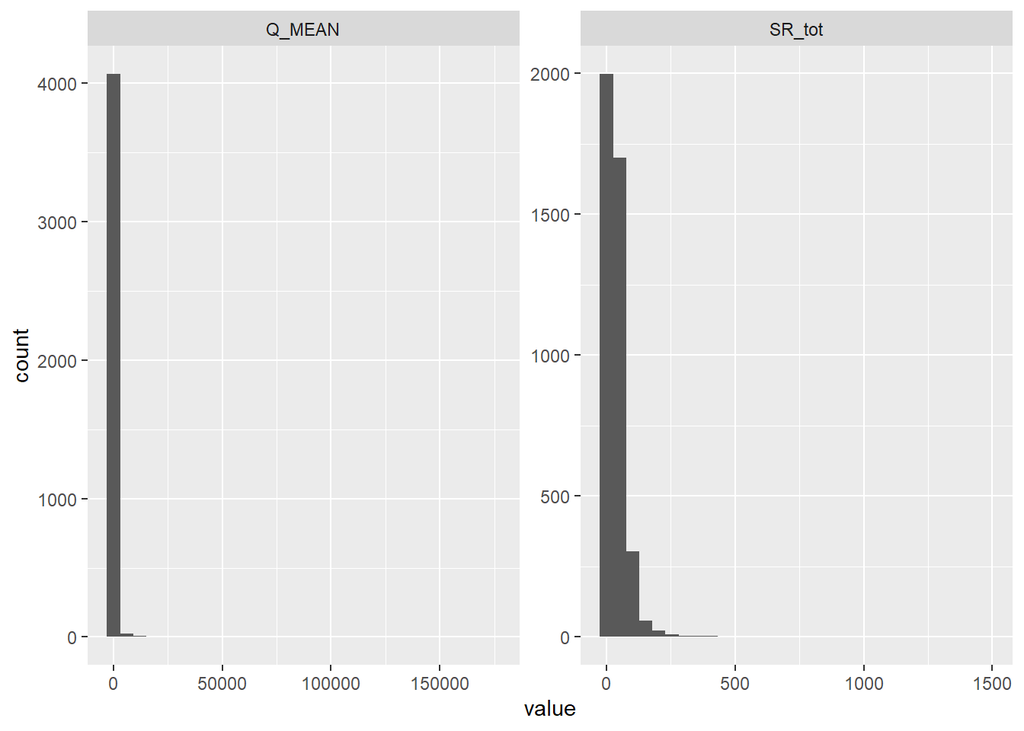

```r
valerioUtils::libinv(c('ggplot2','purrr','tidyr'))
tab_d %>%
  select(-ID,-BAS) %>%
  keep(is.numeric) %>%
  gather() %>%
  ggplot(aes(value)) +
  facet_wrap(~ key, scales = "free") +
  geom_histogram()
```

```r
# names of the variables that need to be transformed to reach a more normalized distribution
variables_to_transform <- tab_d %>% select(-ID,-BAS) %>% keep(is.numeric) %>% colnames

library(bestNormalize)

BN <- list()
tab_d.t <- foreach(i = 1:length(variables_to_transform),.combine = 'cbind') %do% {

  BN[[i]] <- list()
  BN[[i]][[1]] <- bestNormalize(as.data.frame(tab_d)[,variables_to_transform[i]],allow_orderNorm = FALSE)

  val <- scale(BN[[i]][[1]]$x.t)
  BN[[i]][[2]] <- attr(val,"scaled:center")
  BN[[i]][[3]] <- attr(val,"scaled:scale")

  names(BN[[i]]) <- c('BN','center','scale')

  d <- as.data.frame(as.numeric(val))
  colnames(d) <- variables_to_transform[i]

  return( d )

}
names(BN) <- variables_to_transform

# and see what happened with the transformations
BN
```

```
## $SR_tot
## $SR_tot$BN
## Best Normalizing transformation with 4113 Observations
##  Estimated Normality Statistics (Pearson P / df, lower => more normal):
##  - No transform: 23.5494
##  - Box-Cox: 2.3333
##  - Log_b(x+a): 3.0178
##  - sqrt(x+a): 4.3662
##  - arcsinh(x): 2.9431
##  - Yeo-Johnson: 2.3276
## Estimation method: Out-of-sample via CV with 10 folds and 5 repeats
##
## Based off these, bestNormalize chose:
## Standardized Yeo-Johnson Transformation with 4113 nonmissing obs.:
##  Estimated statistics:
##  - lambda = 0.057516
##  - mean (before standardization) = 3.576354
##  - sd (before standardization) = 1.099958
##
## $SR_tot$center
## [1] 8.781505e-17
##
## $SR_tot$scale
## [1] 1
##
##
## $Q_MEAN
## $Q_MEAN$BN
## Best Normalizing transformation with 4113 Observations
##  Estimated Normality Statistics (Pearson P / df, lower => more normal):
##  - No transform: 256.8749
##  - Box-Cox: 1.6999
##  - Log_b(x+a): 1.6925
##  - sqrt(x+a): 43.4837
##  - arcsinh(x): 1.5182
##  - Yeo-Johnson: 1.2169
## Estimation method: Out-of-sample via CV with 10 folds and 5 repeats
##
## Based off these, bestNormalize chose:
## Standardized Yeo-Johnson Transformation with 4113 nonmissing obs.:
##  Estimated statistics:
##  - lambda = -0.1226528
##  - mean (before standardization) = 2.634411
##  - sd (before standardization) = 1.083207
##
## $Q_MEAN$center
## [1] -3.083826e-17
##
## $Q_MEAN$scale
## [1] 1
```

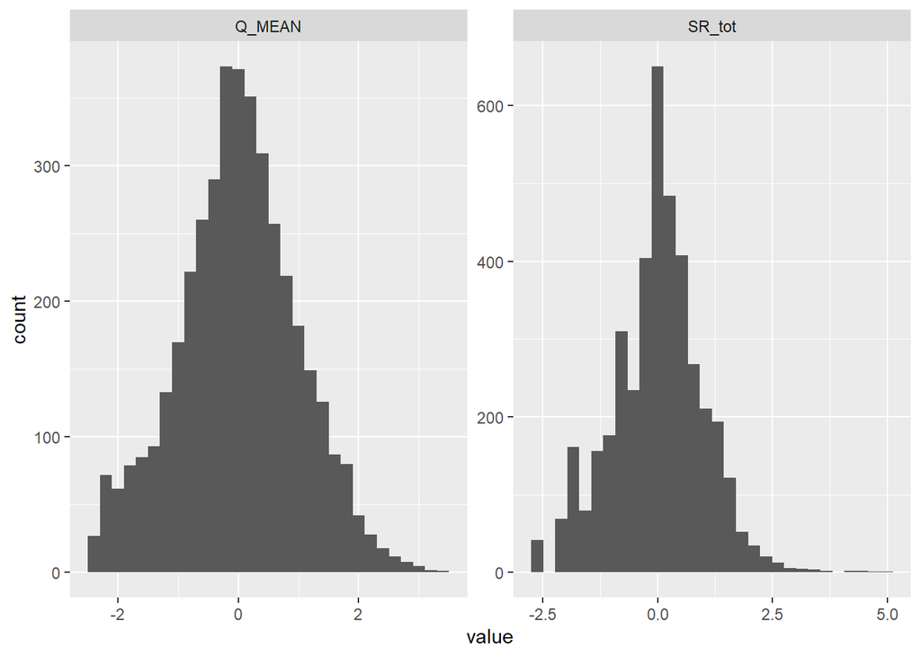

```r
# and check again the distribution
tab_d.t %>%
  gather() %>%
  ggplot(aes(value)) +
  facet_wrap(~ key, scales = "free") +
  geom_histogram()
```

## test mixed effect models

```r
# add the BAS id to the transformed variables table
tab_d.t$BAS <- tab_d$BAS

df <- tab_d.t

# add number of observations per main basin
df <- full_join(df,
                df %>%
                  group_by(BAS) %>%
                  summarise(no_bas = n()))
```

# Case 1: entire dataset

```r
d1 <- df

# number of data points
nrow(d1)
```

```
## [1] 4113
```

```r
# number of basins
length(unique(d1$BAS))
```

```
## [1] 644
```

```r
# number of basins with only one observation?
length(unique(d1$BAS[d1$no_bas == 1]))
```

```
## [1] 390
```

Overall regression

```r
fit <- lm(SR_tot ~ Q_MEAN, data = d1)
summary(fit)
```

```
##
## Call:
## lm(formula = SR_tot ~ Q_MEAN, data = d1)
##
## Residuals:
##     Min      1Q  Median      3Q     Max
## -3.1182 -0.5780  0.1033  0.6127  3.8908
##
## Coefficients:
##              Estimate Std. Error t value Pr(>|t|)
## (Intercept) 4.938e-16  1.474e-02    0.00        1
## Q_MEAN      3.264e-01  1.474e-02   22.14   <2e-16 ***
## ---
## Signif. codes:  0 '***' 0.001 '**' 0.01 '*' 0.05 '.' 0.1 ' ' 1
##
## Residual standard error: 0.9454 on 4111 degrees of freedom
## Multiple R-squared:  0.1065, Adjusted R-squared:  0.1063
## F-statistic: 490.1 on 1 and 4111 DF,  p-value: < 2.2e-16
```

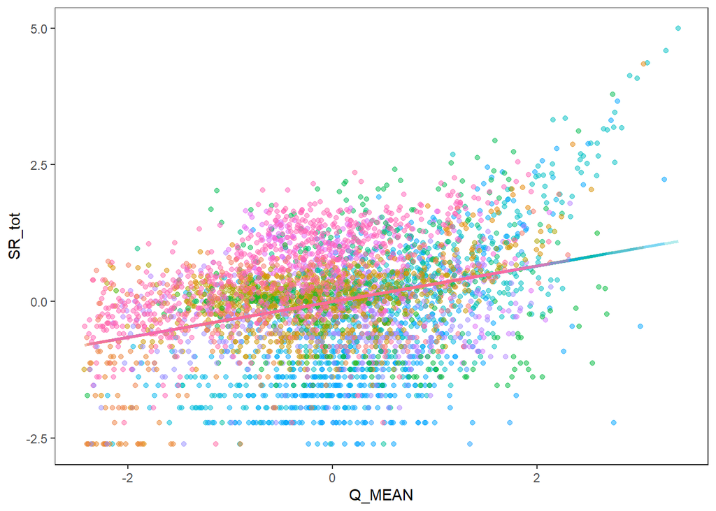

```r
d1$BAS <- as.factor(d1$BAS)
(mm_plot <- ggplot(d1, aes(x = Q_MEAN, y = SR_tot, colour = BAS)) +
    geom_point(alpha = 0.5) +
    theme_bw() +
    geom_line(data = cbind(d1, pred = predict(fit)), aes(y = pred), size = 1, alpha = 0.3) +  # adding predicted line from mixed model
    theme(legend.position = "none",
          panel.grid = element_blank(),
          panel.spacing = unit(2, "lines"))  # adding space between panels
)
```

### HP1: different number of sampling points per waterhsed influences the SDR validity

Run lmer with only random intercept

```r
fit1 <- lmer(SR_tot ~ Q_MEAN + (1 | BAS), REML = F,
             data = d1)
summary(fit1)
```

```
## Linear mixed model fit by maximum likelihood  ['lmerMod']
## Formula: SR_tot ~ Q_MEAN + (1 | BAS)
##    Data: d1
##
##      AIC      BIC   logLik deviance df.resid
##   8569.4   8594.6  -4280.7   8561.4     4109
##
## Scaled residuals:
##     Min      1Q  Median      3Q     Max
## -4.4357 -0.5268 -0.0176  0.4817  5.3112
##
## Random effects:
##  Groups   Name        Variance Std.Dev.
##  BAS      (Intercept) 0.5828   0.7634
##  Residual             0.3700   0.6083
## Number of obs: 4113, groups:  BAS, 644
##
## Fixed effects:
##             Estimate Std. Error t value
## (Intercept) -0.19592    0.03562    -5.5
## Q_MEAN       0.45562    0.01235    36.9
##
## Correlation of Fixed Effects:
##        (Intr)
## Q_MEAN -0.017
```

looks like BAS explains a lot of variance 0.58/(0.37+0.58) * 100 = ~61%

check the R2

```r
# marginal and conditional
MuMIn::r.squaredGLMM(fit1)
```

```
##           R2m       R2c
## [1,] 0.178891 0.6811364
```

```r
# common way
valerioUtils::r.squared(d1$SR_tot,predict(fit1))
```

```
## [1] 0.6741434
```

visualize

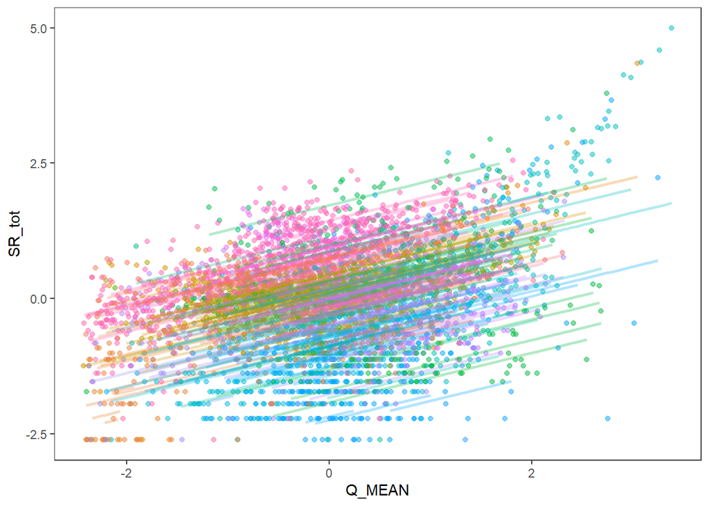

```r
d1$BAS <- as.factor(d1$BAS)
(mm_plot <- ggplot(d1, aes(x = Q_MEAN, y = SR_tot, colour = BAS)) +
    geom_point(alpha = 0.5) +
    theme_bw() +
    geom_line(data = cbind(d1, pred = predict(fit1)), aes(y = pred), size = 1, alpha = 0.3) +  # adding predicted line from mixed model
    theme(legend.position = "none",
          panel.grid = element_blank(),
          panel.spacing = unit(2, "lines"))  # adding space between panels
)
```

**Q1: are the intercept values assigned to the basins with one observation different?**

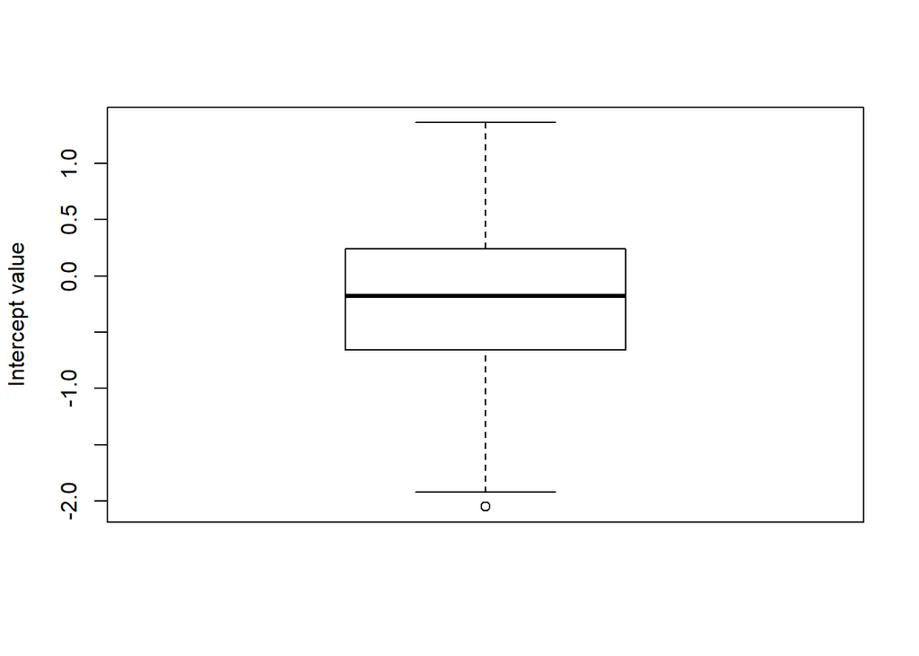

```r
# intercept values for basins with only one observation
boxplot(
  coef(fit1)[[1]][row.names(coef(fit1)[[1]]) %in% unique(d1$BAS[d1$no_bas == 1]),'(Intercept)'],
  ylab = 'Intercept value'
)
```

**R1: Yes, one different intercept value for each basin**

### HP2: different number of sampling points per watershed influences the SDR and different watersheds have different increase rates of SDRs

Run lmer with random intercep and slope

```r
fit1 <- lmer(SR_tot ~ Q_MEAN + (1 + Q_MEAN | BAS), REML = F,
             data = d1)
summary(fit1)
```

```
## Linear mixed model fit by maximum likelihood  ['lmerMod']
## Formula: SR_tot ~ Q_MEAN + (1 + Q_MEAN | BAS)
##    Data: d1
##
##      AIC      BIC   logLik deviance df.resid
##   8044.1   8082.1  -4016.1   8032.1     4107
##
## Scaled residuals:
##     Min      1Q  Median      3Q     Max
## -6.6216 -0.4346  0.0011  0.4340  5.3458
##
## Random effects:
##  Groups   Name        Variance Std.Dev. Corr
##  BAS      (Intercept) 0.55871  0.7475
##           Q_MEAN      0.09062  0.3010   -0.23
##  Residual             0.30412  0.5515
## Number of obs: 4113, groups:  BAS, 644
##
## Fixed effects:
##             Estimate Std. Error t value
## (Intercept) -0.20309    0.03524  -5.762
## Q_MEAN       0.38595    0.02659  14.515
##
## Correlation of Fixed Effects:
##        (Intr)
## Q_MEAN -0.166
```

random intercept explains 0.55/(0.30 + 0.09 + 0.55) * 100 = ~58% of variance

random slope explains 0.09/(0.30 + 0.09 + 0.55) * 100 = ~10% of variance

check the R2

```r
# marginal and conditional
MuMIn::r.squaredGLMM(fit1)
```

```
##            R2m       R2c
## [1,] 0.1351241 0.7241259
```

```r
# common way
valerioUtils::r.squared(d1$SR_tot,predict(fit1))
```

```
## [1] 0.7411204
```

visualize

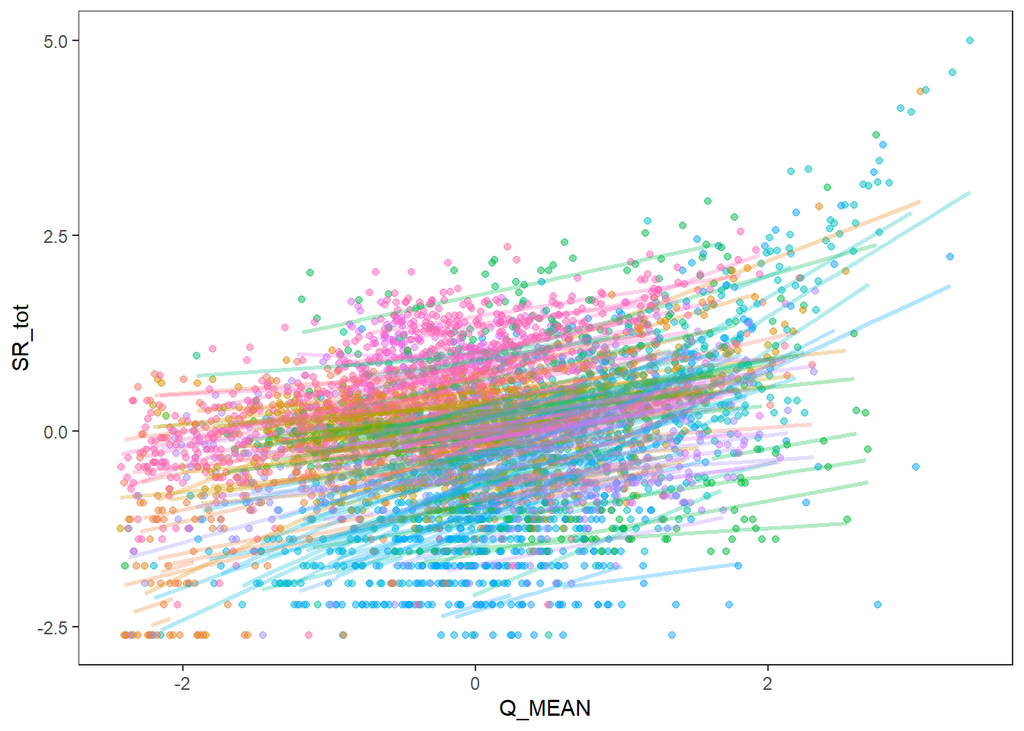

```r
d1$BAS <- as.factor(d1$BAS)
(mm_plot <- ggplot(d1, aes(x = Q_MEAN, y = SR_tot, colour = BAS)) +
    geom_point(alpha = 0.5) +
    theme_bw() +
    geom_line(data = cbind(d1, pred = predict(fit1)), aes(y = pred), size = 1, alpha = 0.3) +  # adding predicted line from mixed model
    theme(legend.position = "none",
          panel.grid = element_blank(),
          panel.spacing = unit(2, "lines"))  # adding space between panels
)
```

the mixed effect model uses one intercept and slope per basin. My doubt is whether this might be inflating the explained variance of the random terms because we have many basins with only one observation

# Case 2: exclude basins with less than 20 observations

Let’s repeat what has been done but using basins with only 20 or more sub-basins

```r
d1 <- df %>% filter(no_bas >= 20)

# number of data points
nrow(d1)
```

```
## [1] 2598
```

```r
# number of basins
length(unique(d1$BAS))
```

```
## [1] 40
```

Overall regression

```r
fit <- lm(SR_tot ~ Q_MEAN, data = d1)
summary(fit)
```

```
##
## Call:
## lm(formula = SR_tot ~ Q_MEAN, data = d1)
##
## Residuals:
##     Min      1Q  Median      3Q     Max
## -3.2736 -0.5573  0.1005  0.5974  3.7204
##
## Coefficients:
##             Estimate Std. Error t value Pr(>|t|)
## (Intercept)  0.08994    0.01843    4.88 1.12e-06 ***
## Q_MEAN       0.35014    0.01773   19.75  < 2e-16 ***
## ---
## Signif. codes:  0 '***' 0.001 '**' 0.01 '*' 0.05 '.' 0.1 ' ' 1
##
## Residual standard error: 0.939 on 2596 degrees of freedom
## Multiple R-squared:  0.1306, Adjusted R-squared:  0.1303
## F-statistic: 389.9 on 1 and 2596 DF,  p-value: < 2.2e-16
```

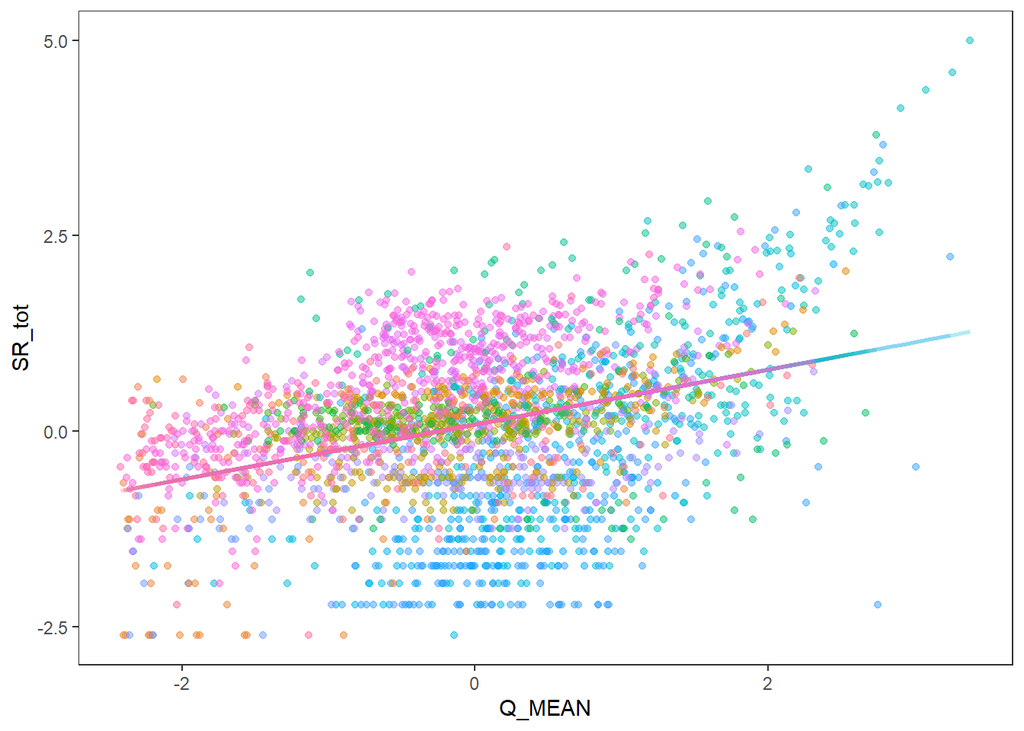

```r
d1$BAS <- as.factor(d1$BAS)
(mm_plot <- ggplot(d1, aes(x = Q_MEAN, y = SR_tot, colour = BAS)) +
    geom_point(alpha = 0.5) +
    theme_bw() +
    geom_line(data = cbind(d1, pred = predict(fit)), aes(y = pred), size = 1, alpha = 0.3) +  # adding predicted line from mixed model
    theme(legend.position = "none",
          panel.grid = element_blank(),
          panel.spacing = unit(2, "lines"))  # adding space between panels
)
```

### HP1: different number of sampling points per waterhsed influences the SDR validity

Run lmer with only random intercept

```r
fit1 <- lmer(SR_tot ~ Q_MEAN + (1 | BAS), REML = F,
             data = d1)
summary(fit1)
```

```
## Linear mixed model fit by maximum likelihood  ['lmerMod']
## Formula: SR_tot ~ Q_MEAN + (1 | BAS)
##    Data: d1
##
##      AIC      BIC   logLik deviance df.resid
##   5324.1   5347.5  -2658.0   5316.1     2594
##
## Scaled residuals:
##     Min      1Q  Median      3Q     Max
## -4.1909 -0.5685 -0.0247  0.5285  4.9042
##
## Random effects:
##  Groups   Name        Variance Std.Dev.
##  BAS      (Intercept) 0.4753   0.6894
##  Residual             0.4259   0.6526
## Number of obs: 2598, groups:  BAS, 40
##
## Fixed effects:
##             Estimate Std. Error t value
## (Intercept)  0.09791    0.11021   0.888
## Q_MEAN       0.47107    0.01551  30.376
##
## Correlation of Fixed Effects:
##        (Intr)
## Q_MEAN 0.017
```

random intercept explains 0.47/(0.47+0.43) * 100 = ~52% of variance

check the R2

```r
# marginal and conditional
MuMIn::r.squaredGLMM(fit1)
```

```
##            R2m       R2c
## [1,] 0.2100657 0.6266616
```

```r
# common way
valerioUtils::r.squared(d1$SR_tot,predict(fit1))
```

```
## [1] 0.5861265
```

visualize

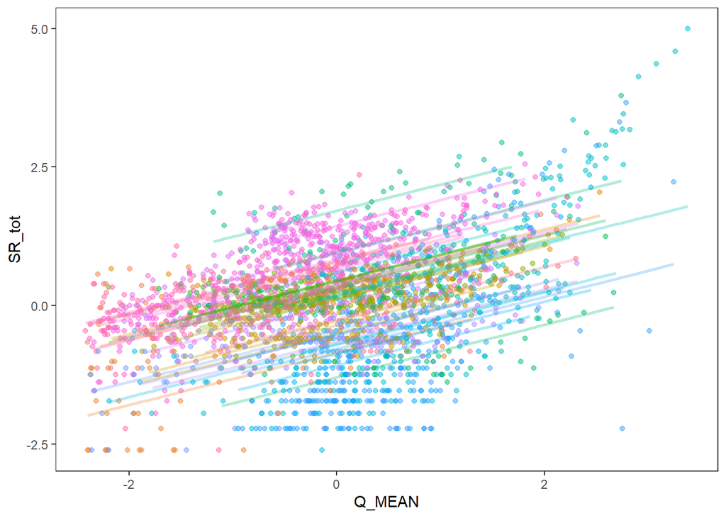

```r
d1$BAS <- as.factor(d1$BAS)
(mm_plot <- ggplot(d1, aes(x = Q_MEAN, y = SR_tot, colour = BAS)) +
    geom_point(alpha = 0.5) +
    theme_bw() +
    geom_line(data = cbind(d1, pred = predict(fit1)), aes(y = pred), size = 1, alpha = 0.3) +  # adding predicted line from mixed model
    theme(legend.position = "none",
          panel.grid = element_blank(),
          panel.spacing = unit(2, "lines"))  # adding space between panels
)
```

### HP2: different number of sampling points per watershed influences the SDR and different watersheds have different increase rates of SDRs

Run lmer with random intercep and slope

```r
fit1 <- lmer(SR_tot ~ Q_MEAN + (1 + Q_MEAN | BAS), REML = F,
             data = d1)
summary(fit1)
```

```
## Linear mixed model fit by maximum likelihood  ['lmerMod']
## Formula: SR_tot ~ Q_MEAN + (1 + Q_MEAN | BAS)
##    Data: d1
##
##      AIC      BIC   logLik deviance df.resid
##   4936.4   4971.6  -2462.2   4924.4     2592
##
## Scaled residuals:
##     Min      1Q  Median      3Q     Max
## -6.1507 -0.4436 -0.0040  0.4722  4.9638
##
## Random effects:
##  Groups   Name        Variance Std.Dev. Corr
##  BAS      (Intercept) 0.55184  0.7429
##           Q_MEAN      0.09971  0.3158   -0.44
##  Residual             0.35287  0.5940
## Number of obs: 2598, groups:  BAS, 40
##
## Fixed effects:
##             Estimate Std. Error t value
## (Intercept)  0.01281    0.11895   0.108
## Q_MEAN       0.39341    0.05332   7.378
##
## Correlation of Fixed Effects:
##        (Intr)
## Q_MEAN -0.404
## convergence code: 0
## Model failed to converge with max|grad| = 0.0130527 (tol = 0.002, component 1)
```

random intercept explains 0.55/(0.55 + 0.10 + 0.36) * 100 = ~54% of variance

random slope explains 0.10/(0.55 + 0.10 + 0.36) * 100 = ~10% of variance

check the R2

```r
# marginal and conditional
MuMIn::r.squaredGLMM(fit1)
```

```
##            R2m       R2c
## [1,] 0.1410182 0.7023078
```

```r
# common way
valerioUtils::r.squared(d1$SR_tot,predict(fit1))
```

```
## [1] 0.6617028
```

visualize

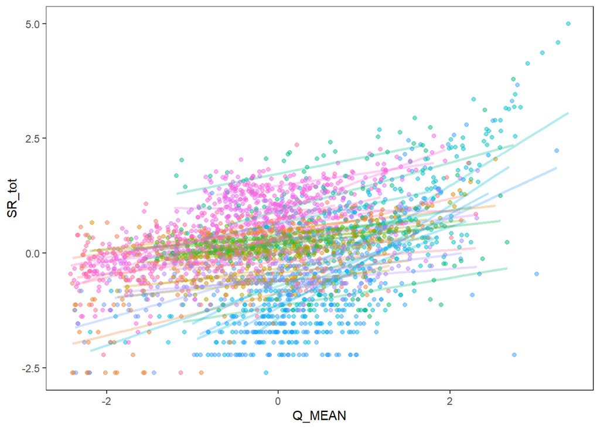

```r
d1$BAS <- as.factor(d1$BAS)
(mm_plot <- ggplot(d1, aes(x = Q_MEAN, y = SR_tot, colour = BAS)) +
    geom_point(alpha = 0.5) +
    theme_bw() +
    geom_line(data = cbind(d1, pred = predict(fit1)), aes(y = pred), size = 1, alpha = 0.3) +  # adding predicted line from mixed model
    theme(legend.position = "none",
          panel.grid = element_blank(),
          panel.spacing = unit(2, "lines"))  # adding space between panels
)
```

multipanel

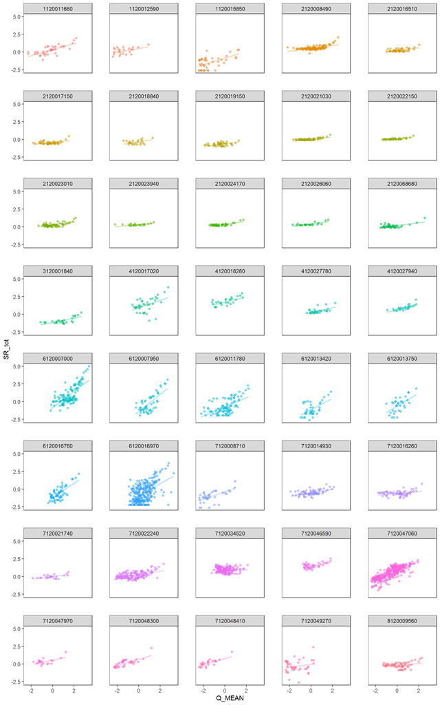

```r
ggplot(d1, aes(x = Q_MEAN, y = SR_tot, colour = BAS)) +
  geom_point(alpha = 0.5) +
  facet_wrap('BAS',ncol = 5) +
  theme_bw() +
  geom_line(data = cbind(d1, pred = predict(fit1)), aes(y = pred), size = 1, alpha = 0.3) +  # adding predicted line from mixed model
  theme(legend.position = "none",
        panel.grid = element_blank(),
        panel.spacing = unit(2, "lines"))  # adding space between panels
```

**Q2: is this last model (random slope and intercept) equivalent to fitting one lm per main basin?**

```r
# one lm for each main basin
(multi_lm <- foreach(id = row.names(coef(fit1)[[1]]),.combine = 'rbind') %do% {

  dt <- d1 %>% filter(BAS == id)
  res <- coef(lm(SR_tot ~ Q_MEAN, data = dt)) %>%
    as.data.frame() %>% t() %>% as.data.frame()# %>% select('Q_MEAN','(Intercept)')
  row.names(res) <- id

  return(res)

})
```

```
##             (Intercept)      Q_MEAN
## 1120011660  0.340939783  0.43803680
## 1120012590  0.516597367  0.25603220
## 1120015850 -0.912465823  0.43633314
## 2120008490  0.517366907  0.20156084
## 2120016510  0.203890456  0.16516795
## 2120017150 -0.447015831  0.10321828
## 2120018840 -0.379741117  0.12491811
## 2120019150 -0.662990462  0.09495256
## 2120021030  0.039274866  0.12582398
## 2120022150  0.072124553  0.11444108
## 2120023010  0.250776320  0.20255701
## 2120023940  0.312923993  0.06295041
## 2120024170  0.363735670  0.18808017
## 2120026060  0.413246573  0.16852531
```

[output cut: 26 more lines]

```r
# results from the lmer with random slope and intercept
(single_lmer <- coef(fit1)[[1]])
```

```
##             (Intercept)     Q_MEAN
## 1120011660  0.331384369  0.4272662
## 1120012590  0.494705709  0.2480888
## 1120015850 -0.865151511  0.4609456
## 2120008490  0.513032811  0.2078995
## 2120016510  0.196287494  0.1993431
## 2120017150 -0.419195340  0.1683368
## 2120018840 -0.331386006  0.2414005
## 2120019150 -0.610557524  0.1821752
## 2120021030  0.049055958  0.1561939
## 2120022150  0.089519286  0.1608536
## 2120023010  0.249465086  0.2160415
## 2120023940  0.323585584  0.1236872
## 2120024170  0.368414215  0.2111079
## 2120026060  0.411124034  0.1996732
```

[output cut: 26 more lines]

```r
# % differences
round((multi_lm - single_lmer)/single_lmer * 100,1)
```

```
##            (Intercept) Q_MEAN
## 1120011660         2.9    2.5
## 1120012590         4.4    3.2
## 1120015850         5.5   -5.3
## 2120008490         0.8   -3.0
## 2120016510         3.9  -17.1
## 2120017150         6.6  -38.7
## 2120018840        14.6  -48.3
## 2120019150         8.6  -47.9
## 2120021030       -19.9  -19.4
## 2120022150       -19.4  -28.9
## 2120023010         0.5   -6.2
## 2120023940        -3.3  -49.1
## 2120024170        -1.3  -10.9
## 2120026060         0.5  -15.6
```

[output cut: 26 more lines]

**R2: it does not seem to be the same thing, somehow the lmer still keeps into account for the other data points when calculating slope and intercept, nice!**